# Practical Machine Learning - Project

Camille Tolentino

11/14/2020

# Overview

This project aims to predict whether or not a specific activity is done correctly or incorrectly based on device accelerometer inputs. Using data from [Groupware Human Activity Recognition Project](http://groupware.les.inf.puc-rio.br/har), a model is generated for the purpose of prediction and tested on a given set.

### Dataset

The training data for this project are available here:

https://d396qusza40orc.cloudfront.net/predmachlearn/pml-training.csv

The test data are available here:

https://d396qusza40orc.cloudfront.net/predmachlearn/pml-testing.csv

# Data Loading and Exploratory Data Analysis

## Data Preparation

The data that we have currently has 160 variables. We first want to split the training set into a training set and a validation set so we can check for the accuracy of different models on the data.

```r
trainurl <- "https://d396qusza40orc.cloudfront.net/predmachlearn/pml-training.csv"
testurl <-"https://d396qusza40orc.cloudfront.net/predmachlearn/pml-testing.csv"
train <-read.csv(trainurl)
testing <-read.csv(testurl)
dim(train); dim(testing)
```

```
## [1] 19622   160
```

```
## [1]  20 160
```

Since we will still be figuring out the best model for the prediction, we split the training set into a training set and validation set.

```r
inTrain <- createDataPartition(y=train$classe,
                               p = 0.7, list = FALSE)
training <-train[inTrain,]
validating <-train[-inTrain,]
```

Next, we check for variables we can possibly omit. To do this we check the variables with nearly zero variation and those variables with more than 95% of observations as NA. We use the training set to determine which variables have to go and apply the same processing to the validation set and test set.

```r
zeroVar <- nearZeroVar(training)
training <- training[,-zeroVar]
validating <- validating[,-zeroVar]
testing <- testing[,-zeroVar]

naObs <- sapply(training, function(x) mean(is.na(x))) > 0.95
training <- training [, naObs == FALSE]
validating <- validating [, naObs == FALSE]
testing <- testing [, naObs == FALSE]

str(training)
```

```
## 'data.frame':    13737 obs. of  59 variables:
##  $ X                   : int  1 2 4 5 6 7 9 10 11 12 ...
##  $ user_name           : chr  "carlitos" "carlitos" "carlitos" "carlitos" ...
##  $ raw_timestamp_part_1: int  1323084231 1323084231 1323084232 1323084232 1323084232 1323084232 1323084232 1323084232 1323084232 1323084232 ...
##  $ raw_timestamp_part_2: int  788290 808298 120339 196328 304277 368296 484323 484434 500302 528316 ...
##  $ cvtd_timestamp      : chr  "05/12/2011 11:23" "05/12/2011 11:23" "05/12/2011 11:23" "05/12/2011 11:23" ...
##  $ num_window          : int  11 11 12 12 12 12 12 12 12 12 ...
##  $ roll_belt           : num  1.41 1.41 1.48 1.48 1.45 1.42 1.43 1.45 1.45 1.43 ...
##  $ pitch_belt          : num  8.07 8.07 8.05 8.07 8.06 8.09 8.16 8.17 8.18 8.18 ...
##  $ yaw_belt            : num  -94.4 -94.4 -94.4 -94.4 -94.4 -94.4 -94.4 -94.4 -94.4 -94.4 ...
##  $ total_accel_belt    : int  3 3 3 3 3 3 3 3 3 3 ...
##  $ gyros_belt_x        : num  0 0.02 0.02 0.02 0.02 0.02 0.02 0.03 0.03 0.02 ...
##  $ gyros_belt_y        : num  0 0 0 0.02 0 0 0 0 0 0 ...
##  $ gyros_belt_z        : num  -0.02 -0.02 -0.03 -0.02 -0.02 -0.02 -0.02 0 -0.02 -0.02 ...
##  $ accel_belt_x        : int  -21 -22 -22 -21 -21 -22 -20 -21 -21 -22 ...
```

[output cut: 45 more lines]

We now have 59 variables left for consideration. Looking at the first 5 however, these are descriptive variables that will be of no help to our calculations. We can then proceed with omitting them as well.

```r
training <- training[,-(1:5)]
validating <- validating[,-(1:5)]
testing <- testing[,-(1:5)]
```

Before we proceed with building our model, we want to see how many of our remaining variables are correlated. To do so, we use `corrplot` to check create a visual correlation matrix for the remaining 54 variables.

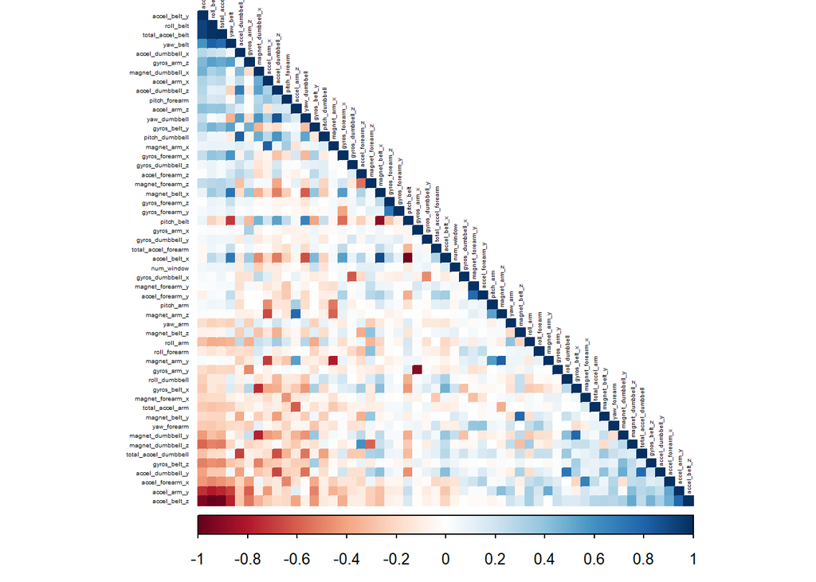

```r
corMatrix <- cor(training[, -54])
corrplot(corMatrix, order = "FPC",
         method = "color", type = "lower",
         tl.cex = 0.3, tl.col = "black")
```

Seeing as we still have quite a number of variables with correlation > 0.8 represented by the darker shades of red and blue, we will use `PCA` as the preprocess function when we use the `caret` train function.

# Methodology Testing

we will be considering different prediction methodologies against the validation set and checking the one with best accuracy in order to choose the final methodology to use on the test set.

## Random Forest

```r
modRF <- train(classe ~., method = "rf",data=training, preProcess="pca")
```

[output not shown]

[output cut: 19 more lines]

[output not shown]

```r
modRF$finalModel
```

```
##
## Call:
##  randomForest(x = x, y = y, mtry = param$mtry)
##                Type of random forest: classification
##                      Number of trees: 500
## No. of variables tried at each split: 2
##
##         OOB estimate of  error rate: 2.29%
## Confusion matrix:
##      A    B    C    D    E class.error
## A 3876   11    9    9    1 0.007680492
## B   41 2574   38    1    4 0.031602709
## C    4   42 2322   22    6 0.030884808
## D    0    3   80 2164    5 0.039076377
## E    0    8   13   18 2486 0.015445545
```

We then want to see the accuracy of this model against the validation set. We do this by using the confusion matrix and then plotting the results.

[figure not shown]

```r
predictRF <- predict(modRF, validating)
cmRF<-confusionMatrix(predictRF, as.factor(validating$classe))
ggplot(data = as.data.frame(cmRF$table),aes(x=Prediction,y=Reference,fill=Freq))+
  geom_tile()+
  theme_light()+
  geom_text(aes(label = Freq),size = 8, color = "white")+
  ggtitle("Random Forest Accuracy = 0.9779")
```